# Propser Loan Data Exploration

## ( Structure of Dataset )

#### The dataset comprised of borrower APRs and traits of 113,937 advances.

#### Most variables are numeric and categorical.

#### The credits included original loan amount.

#### borrower's Prosper rating

#### borrower's expressed month to month pay.

#### just as numerous different elements like borrower's work status.

#### relationship of outstanding debt to take home pay.

#### current advance status and so forth.

### import all packages

```python
import numpy as np
import pandas as pd
import matplotlib.pyplot as plt
import seaborn as sb
%matplotlib inline
```

### load in dataset into a pandas dataframe

```python
df = pd.read_csv('Data/prosperLoanData.csv')
```

### Data Shape

```python
df.shape
```

```
(113937, 81)
```

### Data Information & Details

```python
df.info()
```

```
<class 'pandas.core.frame.DataFrame'>
RangeIndex: 113937 entries, 0 to 113936
Data columns (total 81 columns):
 #   Column                               Non-Null Count   Dtype
---  ------                               --------------   -----
 0   ListingKey                           113937 non-null  object
 1   ListingNumber                        113937 non-null  int64
 2   ListingCreationDate                  113937 non-null  object
 3   CreditGrade                          28953 non-null   object
 4   Term                                 113937 non-null  int64
 5   LoanStatus                           113937 non-null  object
 6   ClosedDate                           55089 non-null   object
 7   BorrowerAPR                          113912 non-null  float64
 8   BorrowerRate                         113937 non-null  float64
 9   LenderYield                          113937 non-null  float64
```

[output cut: 73 more lines]

### Data Description

```python
df.describe()
```

|  | ListingNumber | Term | BorrowerAPR | BorrowerRate | LenderYield | EstimatedEffectiveYield | EstimatedLoss | EstimatedReturn | ProsperRating (numeric) | ProsperScore | ... | LP_ServiceFees | LP_CollectionFees | LP_GrossPrincipalLoss | LP_NetPrincipalLoss | LP_NonPrincipalRecoverypayments | PercentFunded | Recommendations | InvestmentFromFriendsCount | InvestmentFromFriendsAmount | Investors |
| --- | --- | --- | --- | --- | --- | --- | --- | --- | --- | --- | --- | --- | --- | --- | --- | --- | --- | --- | --- | --- | --- |
| count | 1.139370e+05 | 113937.000000 | 113912.000000 | 113937.000000 | 113937.000000 | 84853.000000 | 84853.000000 | 84853.000000 | 84853.000000 | 84853.000000 | ... | 113937.000000 | 113937.000000 | 113937.000000 | 113937.000000 | 113937.000000 | 113937.000000 | 113937.000000 | 113937.000000 | 113937.000000 | 113937.000000 |
| mean | 6.278857e+05 | 40.830248 | 0.218828 | 0.192764 | 0.182701 | 0.168661 | 0.080306 | 0.096068 | 4.072243 | 5.950067 | ... | -54.725641 | -14.242698 | 700.446342 | 681.420499 | 25.142686 | 0.998584 | 0.048027 | 0.023460 | 16.550751 | 80.475228 |
| std | 3.280762e+05 | 10.436212 | 0.080364 | 0.074818 | 0.074516 | 0.068467 | 0.046764 | 0.030403 | 1.673227 | 2.376501 | ... | 60.675425 | 109.232758 | 2388.513831 | 2357.167068 | 275.657937 | 0.017919 | 0.332353 | 0.232412 | 294.545422 | 103.239020 |
| min | 4.000000e+00 | 12.000000 | 0.006530 | 0.000000 | -0.010000 | -0.182700 | 0.004900 | -0.182700 | 1.000000 | 1.000000 | ... | -664.870000 | -9274.750000 | -94.200000 | -954.550000 | 0.000000 | 0.700000 | 0.000000 | 0.000000 | 0.000000 | 1.000000 |
| 25% | 4.009190e+05 | 36.000000 | 0.156290 | 0.134000 | 0.124200 | 0.115670 | 0.042400 | 0.074080 | 3.000000 | 4.000000 | ... | -73.180000 | 0.000000 | 0.000000 | 0.000000 | 0.000000 | 1.000000 | 0.000000 | 0.000000 | 0.000000 | 2.000000 |
| 50% | 6.005540e+05 | 36.000000 | 0.209760 | 0.184000 | 0.173000 | 0.161500 | 0.072400 | 0.091700 | 4.000000 | 6.000000 | ... | -34.440000 | 0.000000 | 0.000000 | 0.000000 | 0.000000 | 1.000000 | 0.000000 | 0.000000 | 0.000000 | 44.000000 |
| 75% | 8.926340e+05 | 36.000000 | 0.283810 | 0.250000 | 0.240000 | 0.224300 | 0.112000 | 0.116600 | 5.000000 | 8.000000 | ... | -13.920000 | 0.000000 | 0.000000 | 0.000000 | 0.000000 | 1.000000 | 0.000000 | 0.000000 | 0.000000 | 115.000000 |
| max | 1.255725e+06 | 60.000000 | 0.512290 | 0.497500 | 0.492500 | 0.319900 | 0.366000 | 0.283700 | 7.000000 | 11.000000 | ... | 32.060000 | 0.000000 | 25000.000000 | 25000.000000 | 21117.900000 | 1.012500 | 39.000000 | 33.000000 | 25000.000000 | 1189.000000 |

8 rows × 61 columns

```python
df.head()
```

|  | ListingKey | ListingNumber | ListingCreationDate | CreditGrade | Term | LoanStatus | ClosedDate | BorrowerAPR | BorrowerRate | LenderYield | ... | LP_ServiceFees | LP_CollectionFees | LP_GrossPrincipalLoss | LP_NetPrincipalLoss | LP_NonPrincipalRecoverypayments | PercentFunded | Recommendations | InvestmentFromFriendsCount | InvestmentFromFriendsAmount | Investors |
| --- | --- | --- | --- | --- | --- | --- | --- | --- | --- | --- | --- | --- | --- | --- | --- | --- | --- | --- | --- | --- | --- |
| 0 | 1021339766868145413AB3B | 193129 | 2007-08-26 19:09:29.263000000 | C | 36 | Completed | 2009-08-14 00:00:00 | 0.16516 | 0.1580 | 0.1380 | ... | -133.18 | 0.0 | 0.0 | 0.0 | 0.0 | 1.0 | 0 | 0 | 0.0 | 258 |
| 1 | 10273602499503308B223C1 | 1209647 | 2014-02-27 08:28:07.900000000 | NaN | 36 | Current | NaN | 0.12016 | 0.0920 | 0.0820 | ... | 0.00 | 0.0 | 0.0 | 0.0 | 0.0 | 1.0 | 0 | 0 | 0.0 | 1 |
| 2 | 0EE9337825851032864889A | 81716 | 2007-01-05 15:00:47.090000000 | HR | 36 | Completed | 2009-12-17 00:00:00 | 0.28269 | 0.2750 | 0.2400 | ... | -24.20 | 0.0 | 0.0 | 0.0 | 0.0 | 1.0 | 0 | 0 | 0.0 | 41 |
| 3 | 0EF5356002482715299901A | 658116 | 2012-10-22 11:02:35.010000000 | NaN | 36 | Current | NaN | 0.12528 | 0.0974 | 0.0874 | ... | -108.01 | 0.0 | 0.0 | 0.0 | 0.0 | 1.0 | 0 | 0 | 0.0 | 158 |
| 4 | 0F023589499656230C5E3E2 | 909464 | 2013-09-14 18:38:39.097000000 | NaN | 36 | Current | NaN | 0.24614 | 0.2085 | 0.1985 | ... | -60.27 | 0.0 | 0.0 | 0.0 | 0.0 | 1.0 | 0 | 0 | 0.0 | 20 |

5 rows × 81 columns

## ( Main features of interest )

### 1- Borrower Annual Percentage Rate.....2- LoanOriginalAmount

### 3- StatedMonthlyIncome..........................4- Term

### 5- EmploymentStatus ..............................6- Prosper Score

### 7- Credit Grade..........................................8- Estimated Returns

### 9- Income Ratio.........................................10-Debt to Income Ratio

# Univariate Exploration

## 1-BorrowerAPR

```python
B_APR = df.BorrowerAPR
B_APR.describe()
```

```
count    113912.000000
mean          0.218828
std           0.080364
min           0.006530
25%           0.156290
50%           0.209760
75%           0.283810
max           0.512290
Name: BorrowerAPR, dtype: float64
```

```python
# drop null rows
B_APR.dropna(axis = 0, inplace = True)
```

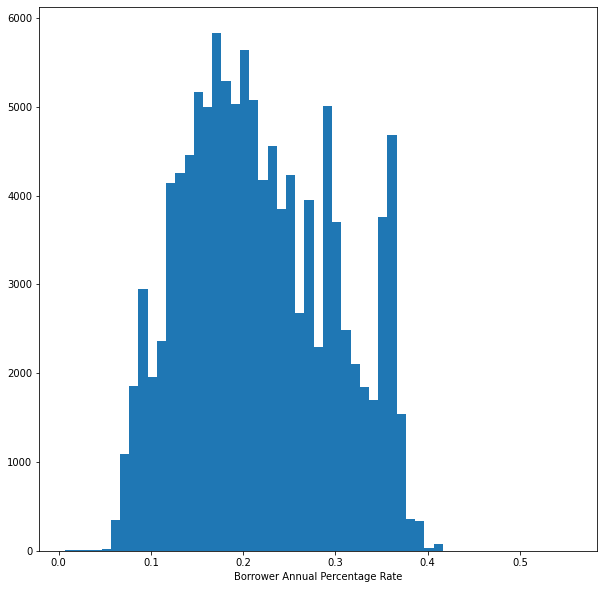

```python
B_APR = df.BorrowerAPR
b = np.arange(B_APR.min(),B_APR.max()+0.05,0.01)
plt.figure(figsize=[10,10])
plt.hist(data = df, x = 'BorrowerAPR', bins=b)
plt.xlabel('Borrower Annual Percentage Rate')
```

### Small amount less than 0.1 APR

### Large amount between 0.15 and 0.3 APR

### Few loans greater than or equal 0.4 APR

## 2-Loan Original Amount

```python
LOA = df.LoanOriginalAmount
LOA.describe()
```

```
count    113937.00000
mean       8337.01385
std        6245.80058
min        1000.00000
25%        4000.00000
50%        6500.00000
75%       12000.00000
max       35000.00000
Name: LoanOriginalAmount, dtype: float64
```

```python
# drop null rows
LOA.dropna(axis = 0, inplace = True)
```

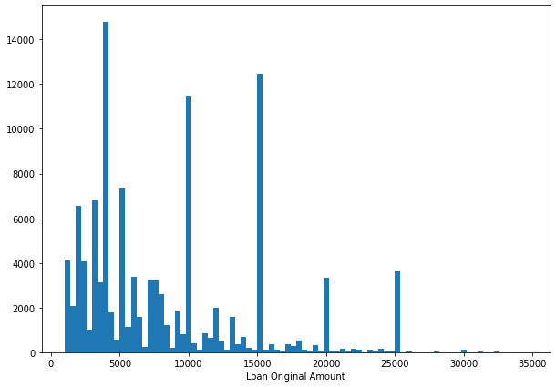

```python
b = np.arange(LOA.min(),LOA.max(),400)
plt.figure(figsize=[10,7])
plt.hist(data = df, x = 'LoanOriginalAmount', bins=b)
plt.xlabel('Loan Original Amount')
```

### Large frequency at 4000 , 10000, 15000 , 20000 , 25000

### Small frequency less than 4000 and between (5000 , 10000) and between (10000, 15000)

## 3-State Monthly Income

```python
SMI = df.StatedMonthlyIncome
SMI.describe()
```

```
count    1.139370e+05
mean     5.608026e+03
std      7.478497e+03
min      0.000000e+00
25%      3.200333e+03
50%      4.666667e+03
75%      6.825000e+03
max      1.750003e+06
Name: StatedMonthlyIncome, dtype: float64
```

```python
# drop null rows
SMI.dropna(axis = 0, inplace = True)
```

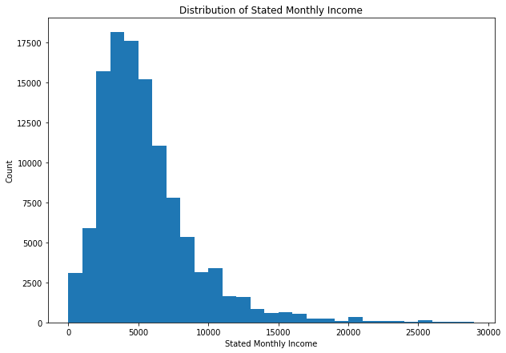

```python
SMI = df.StatedMonthlyIncome
b = np.arange(0,30000,1000)
plt.figure(figsize=[10,7])
plt.hist(data = df, x = 'StatedMonthlyIncome', bins=b)
plt.xlabel('Stated Monthly Income')
plt.ylabel('Count')
plt.title('Distribution of Stated Monthly Income');
```

### The Most Stated Monthly Income between (3500 , 7000)

## 4- Term

```python
T = df.Term
T.describe()
```

```
count    113937.000000
mean         40.830248
std          10.436212
min          12.000000
25%          36.000000
50%          36.000000
75%          36.000000
max          60.000000
Name: Term, dtype: float64
```

```python
# drop null rows
T.dropna(axis = 0, inplace = True)
```

```python
T.value_counts()
```

```
36    87778
60    24545
12     1614
Name: Term, dtype: int64
```

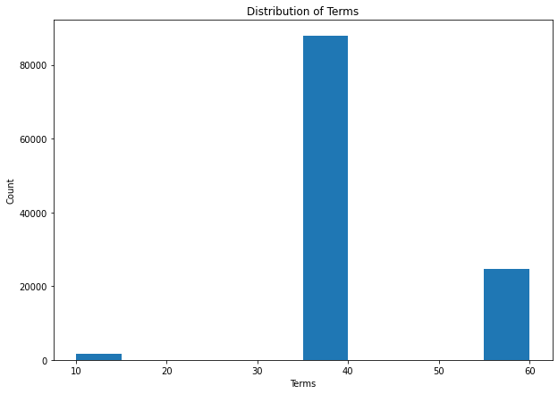

```python
b = np.arange(10,65,5)
plt.figure(figsize=[10,7])
plt.hist(data = df, x = 'Term', bins=b)
plt.xlabel('Terms')
plt.ylabel('Count')
plt.title('Distribution of Terms');
```

### Terms are 12 , 36 and 60 Months

### The most Term is 36 months

## 5-Emplyment Status

```python
ES = df.EmploymentStatus
ES.describe()
```

```
count       111682
unique           8
top       Employed
freq         67322
Name: EmploymentStatus, dtype: object
```

```python
# drop null rows
ES.dropna(axis = 0, inplace = True)
```

```python
ES.value_counts()
```

```
Employed         67322
Full-time        26355
Self-employed     6134
Not available     5347
Other             3806
Part-time         1088
Not employed       835
Retired            795
Name: EmploymentStatus, dtype: int64
```

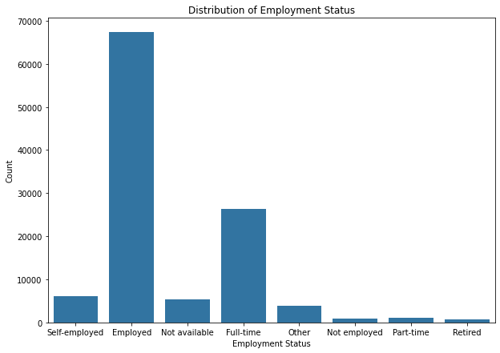

```python
plt.figure(figsize=[10,7])
sb.countplot(data=df , x = 'EmploymentStatus', color=sb.color_palette()[0])
plt.xlabel('Employment Status')
plt.ylabel('Count')
plt.title('Distribution of Employment Status');
```

### Most of borrowers are Employed and Full-time.

## 6- Prosper Score

```python
PS = df.ProsperScore
PS.describe()
```

```
count    84853.000000
mean         5.950067
std          2.376501
min          1.000000
25%          4.000000
50%          6.000000
75%          8.000000
max         11.000000
Name: ProsperScore, dtype: float64
```

```python
# drop null rows
PS.dropna(axis = 0, inplace = True)
```

```python
PS.value_counts()
```

```
4.0     12595
6.0     12278
8.0     12053
7.0     10597
5.0      9813
3.0      7642
9.0      6911
2.0      5766
10.0     4750
11.0     1456
1.0       992
Name: ProsperScore, dtype: int64
```

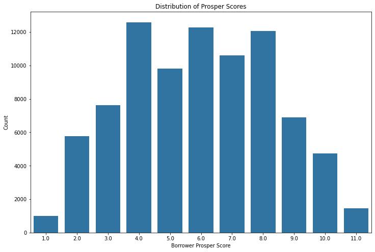

```python
plt.figure(figsize=[12,8])
sb.countplot(data=df , x = 'ProsperScore' , color=sb.color_palette()[0])
plt.xlabel('Borrower Prosper Score')
plt.ylabel('Count')
plt.title('Distribution of Prosper Scores');
```

### Scores of the borrowers between 1 to 11

### The most Borrwer Prosper scores are 4 , 6 , 8

# 7- Credit Grade

```python
CG = df.CreditGrade
CG.describe()
```

```
count     28953
unique        8
top           C
freq       5649
Name: CreditGrade, dtype: object
```

```python
# drop null rows
CG.dropna(axis = 0, inplace = True)
```

```python
CG.value_counts()
```

```
C     5649
D     5153
B     4389
AA    3509
HR    3508
A     3315
E     3289
NC     141
Name: CreditGrade, dtype: int64
```

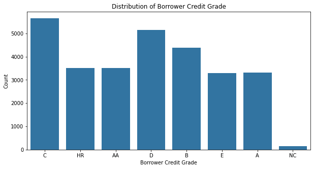

```python
plt.figure(figsize=[10,5])
sb.countplot(data=df , x = 'CreditGrade',color=sb.color_palette()[0])
plt.xlabel('Borrower Credit Grade')
plt.ylabel('Count')
plt.title('Distribution of Borrower Credit Grade');
```

## 8- Estimated Returns

```python
ER = df.EstimatedReturn
ER.describe()
```

```
count    84853.000000
mean         0.096068
std          0.030403
min         -0.182700
25%          0.074080
50%          0.091700
75%          0.116600
max          0.283700
Name: EstimatedReturn, dtype: float64
```

```python
# drop null rows without an estimated return
ER.dropna(axis = 0, inplace = True)
```

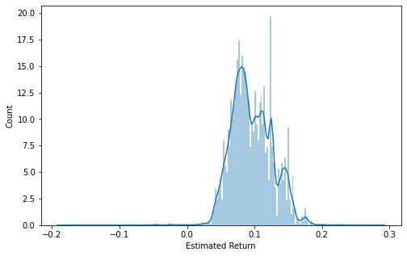

```python
# histogram plot
plt.figure(figsize = [8,5])
sb.distplot(ER, bins = 200)
plt.xlabel('Estimated Return')
plt.ylabel('Count');
```

### Most of our loans have an estimated return between 0% and 20%

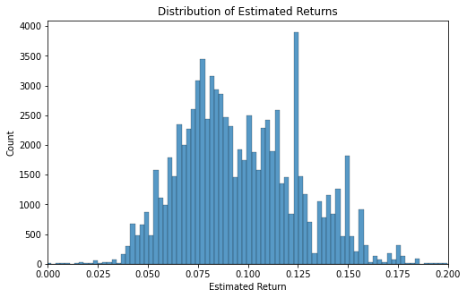

```python
plt.figure(figsize = [8,5])
sb.histplot(ER, bins = 200)
plt.xlim(0, .2)
plt.xlabel('Estimated Return')
plt.ylabel('Count')
plt.title('Distribution of Estimated Returns');
```

### The largest bin falls right around 12.5%

### There are some peaks between 5% to 12.5% and 15%.

# 9- Income Ratio

```python
IR =df.IncomeRange
IR.describe()
```

```
count             113937
unique                 8
top       $25,000-49,999
freq               32192
Name: IncomeRange, dtype: object
```

```python
IR.value_counts()
```

```
$25,000-49,999    32192
$50,000-74,999    31050
$100,000+         17337
$75,000-99,999    16916
Not displayed      7741
$1-24,999          7274
Not employed        806
$0                  621
Name: IncomeRange, dtype: int64
```

## work on data to Simplify Visualization

```python
df['IncomeRange'].replace(['Not employed', 'Not displayed'], '$0', inplace = True)
ordinal_rating = ['$100,000+', '$75,000-99,999', '$50,000-74,999', '$25,000-49,999', '$1-24,999', '$0']
ordered_var = pd.api.types.CategoricalDtype(ordered = True, categories = ordinal_rating)
df['IncomeRange'] = df['IncomeRange'].astype(ordered_var)

rate_order = ['HR','E','D','C','B','A','AA']
ordered_var = pd.api.types.CategoricalDtype(ordered = True,categories = rate_order)
df['ProsperRating (Alpha)'] = df['ProsperRating (Alpha)'].astype(ordered_var)
```

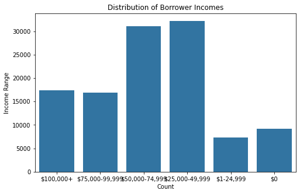

```python
plt.figure(figsize = [8, 5])
sb.countplot(data = df, x = 'IncomeRange',color=sb.color_palette()[0])
plt.ylabel('Income Range')
plt.xlabel('Count')
plt.title('Distribution of Borrower Incomes');
```

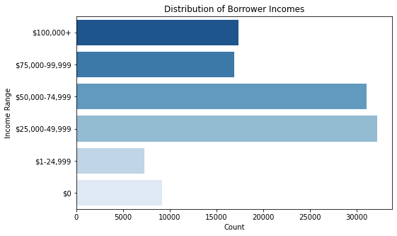

```python
plt.figure(figsize = [8, 5])
sb.countplot(data = df, y = 'IncomeRange',palette = "Blues_r")
plt.ylabel('Income Range')
plt.xlabel('Count')
plt.title('Distribution of Borrower Incomes');
```

### The number of borrowers for the 25k-50k range is the same as the 50k-75k range.

### The amount of borrowers in the 75k-100k range is the same as that over 100k Income.

# 10-Debt to Income Ratio

```python
DIR = df.DebtToIncomeRatio
DIR.describe()
```

```
count    105383.000000
mean          0.275947
std           0.551759
min           0.000000
25%           0.140000
50%           0.220000
75%           0.320000
max          10.010000
Name: DebtToIncomeRatio, dtype: float64
```

```python
# drop null rows without an estimated return
DIR.dropna(axis = 0, inplace = True)
```

```python
DIR.value_counts()
```

```
0.18000    4132
0.22000    3687
0.17000    3616
0.14000    3553
0.20000    3481
           ...
0.06375       1
0.06281       1
0.19960       1
0.17775       1
0.23284       1
Name: DebtToIncomeRatio, Length: 1207, dtype: int64
```

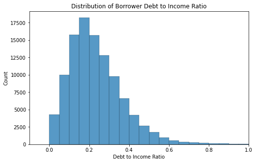

```python
plt.figure(figsize = [8,5])
sb.histplot(df.DebtToIncomeRatio, bins = 200)
plt.xlim(-.1, 1)
plt.xlabel('Debt to Income Ratio')
plt.ylabel('Count')
plt.title('Distribution of Borrower Debt to Income Ratio');
```

### It appears that most borrowers have a debt to income around 0.2

# Bivariate Exploration

```python
numeric_variables_1 = ['LoanOriginalAmount', 'BorrowerAPR', 'StatedMonthlyIncome']
numeric_variables_2 = ['DebtToIncomeRatio', 'EstimatedReturn']
categorical_variables_1 = ['Term', 'CreditGrade', 'EmploymentStatus']
categorical_variables_2 = ['IncomeRange','ProsperRating (Alpha)']
```

# Debt To Income Ratio , Estimated Return {HeatMap}

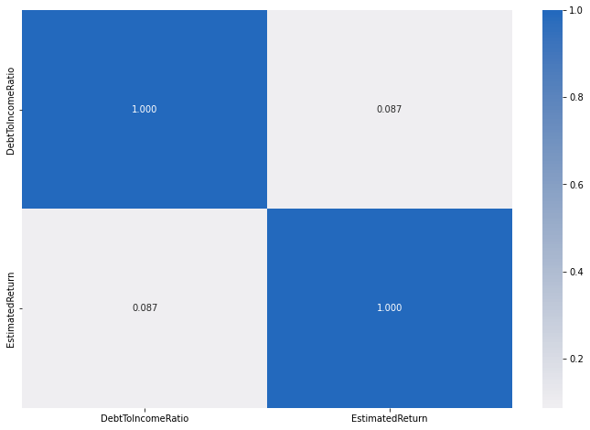

```python
# correlation plot
plt.figure(figsize = [12, 8])
sb.heatmap(df[numeric_variables_2].corr(), annot = True, fmt = '.3f',cmap = 'vlag_r', center = 0);
```

# Debt To Income Ratio , Estimated Return {PairGrid}

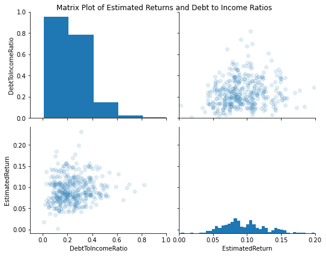

```python
samples = np.random.choice(df.shape[0], int(df.shape[0]*.005), replace = False)
df_samp = df.loc[samples,:]
g = sb.PairGrid(data = df_samp, vars = numeric_variables_2, height=3, aspect = 1.25)
g = g.map_diag(plt.hist, bins = 50)
g.map_offdiag(plt.scatter, alpha = 1/8)
g.axes[0,0].set_ylim(0,1)
g.axes[0,0].set_xlim(-.1,1)
g.axes[0,1].set_xlim(0,.2)
g.fig.suptitle('Matrix Plot of Estimated Returns and Debt to Income Ratios')
g.fig.subplots_adjust(top = .95);
```

#### There doesn't appear to be a correlation between any of the numeric variables.

#### May borrowers with a high debt to income ratio to be riskier

# Loan Original Amount , Borrower APR, Stated Monthly Income {HeatMap}

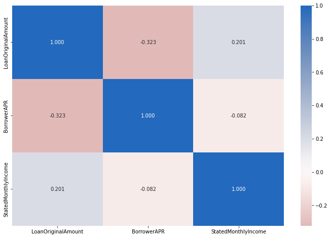

```python
# correlation plot
plt.figure(figsize = [12, 8])
sb.heatmap(df[numeric_variables_1].corr(), annot = True, fmt = '.3f',cmap = 'vlag_r', center = 0);
```

# Loan Original Amount , Borrower APR, Stated Monthly Income {PairGrid}

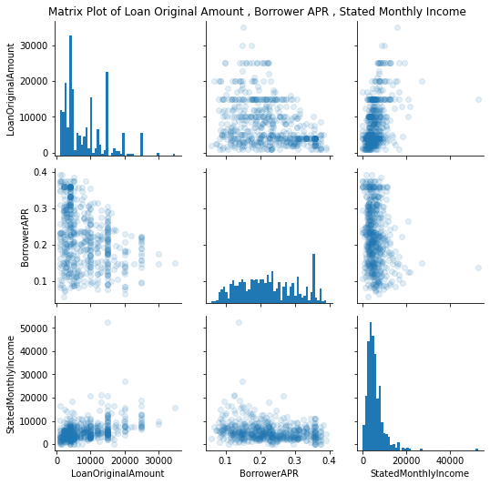

```python
samples = np.random.choice(df.shape[0], int(df.shape[0]*.005), replace = False)
df_samp = df.loc[samples,:]
g = sb.PairGrid(data = df_samp, vars = numeric_variables_1)
g = g.map_diag(plt.hist, bins = 50)
g.map_offdiag(plt.scatter, alpha = 1/8)
g.fig.suptitle('Matrix Plot of Loan Original Amount , Borrower APR , Stated Monthly Income')
g.fig.subplots_adjust(top = .95);
```

### The correlation coefficient of borrower APR and loan original amount is Negative, that is the more the loan amount, the lower the APR.

### The loan original amount is positively correlated with the stated monthly income, borrowers with more monthly income could loan more money.

# IncomeRange , EstimatedReturn {BoxPlot}

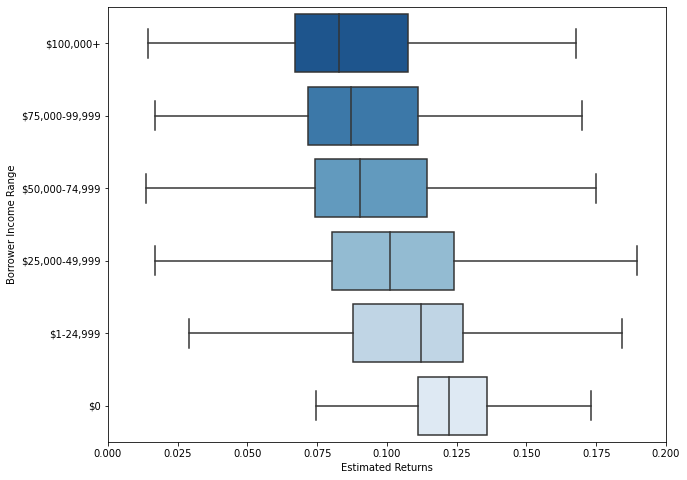

```python
plt.figure(figsize = [10, 8])
base_color = sb.color_palette()[0]
sb.boxplot(data = df, y = 'IncomeRange', x = 'EstimatedReturn', palette = "Blues_r", showfliers = False)
plt.xlim(0,.2)
plt.ylabel('Borrower Income Range')
plt.xlabel('Estimated Returns')
```

### the borrowers income increases, the median estimated return decreases.

### high income borrowers which drive the highest credit rating interest rates down.

# ProsperRating (Alpha) , EstimatedReturn {BoxPlot}

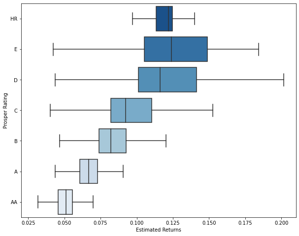

```python
plt.figure(figsize = [10, 8])
base_color = sb.color_palette()[0]
sb.boxplot(data = df, y = 'ProsperRating (Alpha)', x = 'EstimatedReturn', palette = "Blues_r", showfliers = False)
plt.xlim(0.02,.21)
plt.ylabel('Prosper Rating')
plt.xlabel('Estimated Returns')
```

### a borrowers credit rating increases, the median estimated return greatly decreases.

### for the higher risk, the interest rate for the loan also increases.

# IncomeRange , ProsperRating (Alpha) {clustered bar chart}

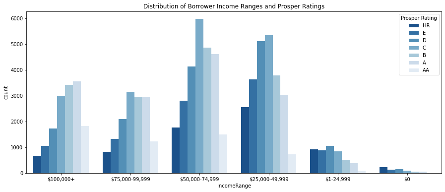

```python
plt.figure(figsize = [15,6])
ax = sb.countplot(data = df, x = 'IncomeRange', hue = 'ProsperRating (Alpha)',palette = 'Blues_r')
ax.legend(title = 'Prosper Rating')
plt.title('Distribution of Borrower Income Ranges and Prosper Ratings')
```

### higher incomes correlate to a higher credit rating qualifying the borrower for the best (lowest) interest rates.

# Term , ProsperRating (Alpha) {clustered bar chart}

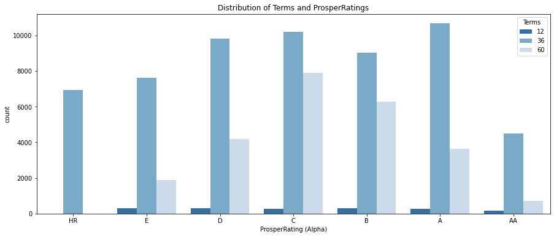

```python
plt.figure(figsize = [15,6])
ax = sb.countplot(data = df, x = 'ProsperRating (Alpha)', hue ='Term' ,palette = 'Blues_r')
ax.legend(title = 'Terms')
plt.title('Distribution of Terms and ProsperRatings')
```

### there are more 60 month loans on B and C ratings.

### There is only 36 months loans for HR rating borrowers.

# EmploymentStatus , Term {clustered bar chart}

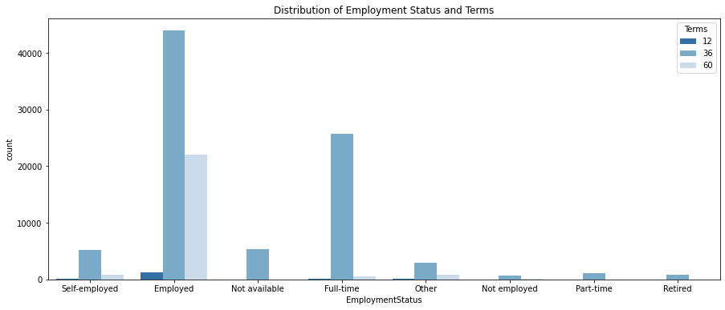

```python
plt.figure(figsize = [15,6])
ax = sb.countplot(data = df, x = 'EmploymentStatus', hue ='Term' ,palette = 'Blues_r')
ax.legend(title = 'Terms')
plt.title('Distribution of Employment Status and Terms')
```

# EmploymentStatus , ProsperRating (Alpha) {clustered bar chart}

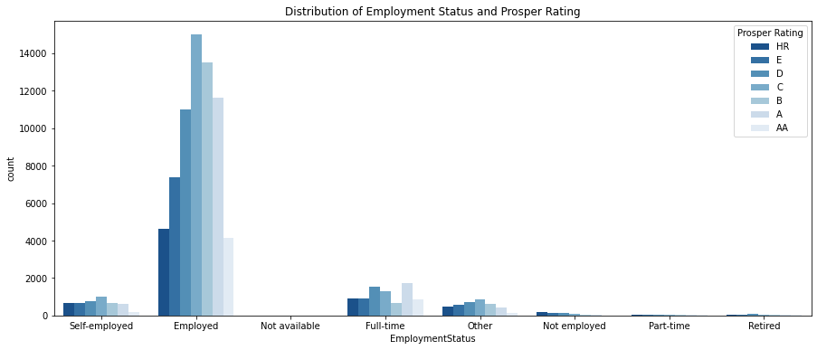

```python
plt.figure(figsize = [15,6])
ax = sb.countplot(data = df, x = 'EmploymentStatus', hue ='ProsperRating (Alpha)' ,palette = 'Blues_r')
ax.legend(title = 'Prosper Rating')
plt.title('Distribution of Employment Status and Prosper Rating')
```

## (Term , ProsperRating , EmploymentStatus) with LoanOriginalAmount {BoxPlot}

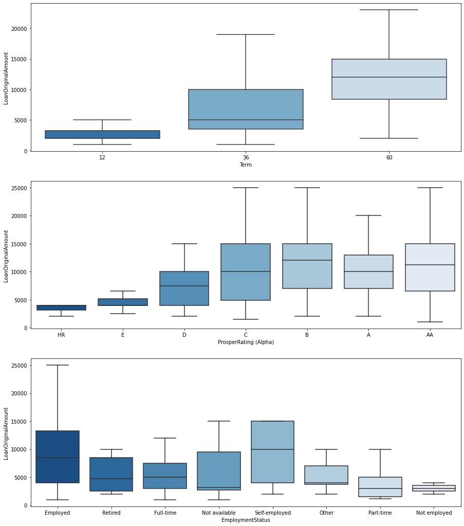

```python
samples = np.random.choice(df.shape[0], int(df.shape[0]*.005), replace = False)
df_samp = df.loc[samples,:]
# boxplots
plt.figure(figsize = [15, 18])
plt.subplot(3, 1, 1)
base_color = sb.color_palette()[0]
sb.boxplot(data = df_samp, x = 'Term', y = 'LoanOriginalAmount', palette = "Blues_r", showfliers = False)

plt.subplot(3, 1, 2)
base_color = sb.color_palette()[0]
sb.boxplot(data = df_samp, x = 'ProsperRating (Alpha)', y = 'LoanOriginalAmount', palette = "Blues_r", showfliers = False);

plt.subplot(3, 1, 3)
base_color = sb.color_palette()[0]
sb.boxplot(data = df_samp, x = 'EmploymentStatus', y = 'LoanOriginalAmount', palette = "Blues_r", showfliers = False);
```

### loan amount is increased with the increase of loan term

### Borrowers with better rating also have large loan amount

### Employed, self-employed and full time borrowers have more loan amount than part-time, retired and not employed borrowers.

## (Term , ProsperRating , EmploymentStatus) with BorrowerAPR {BoxPlot}

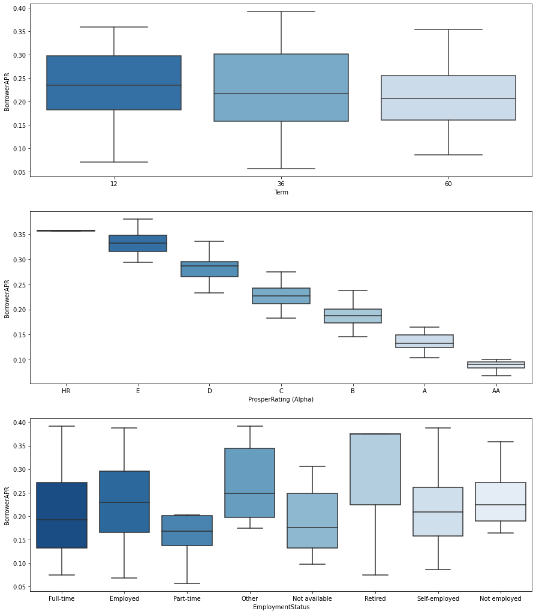

```python
samples = np.random.choice(df.shape[0], int(df.shape[0]*.005), replace = False)
df_samp = df.loc[samples,:]
# boxplots
plt.figure(figsize = [15, 18])
plt.subplot(3, 1, 1)
base_color = sb.color_palette()[0]
sb.boxplot(data = df_samp, x = 'Term', y = 'BorrowerAPR', palette = "Blues_r", showfliers = False)

plt.subplot(3, 1, 2)
base_color = sb.color_palette()[0]
sb.boxplot(data = df_samp, x = 'ProsperRating (Alpha)', y = 'BorrowerAPR', palette = "Blues_r", showfliers = False);

plt.subplot(3, 1, 3)
base_color = sb.color_palette()[0]
sb.boxplot(data = df_samp, x = 'EmploymentStatus', y = 'BorrowerAPR', palette = "Blues_r", showfliers = False);
```

### The borrower APR decreases with the better rating.

### Borrowers with the best Prosper ratings have the lowest APR.

## (Term , ProsperRating , EmploymentStatus) with StatedMonthlyIncome {BoxPlot}

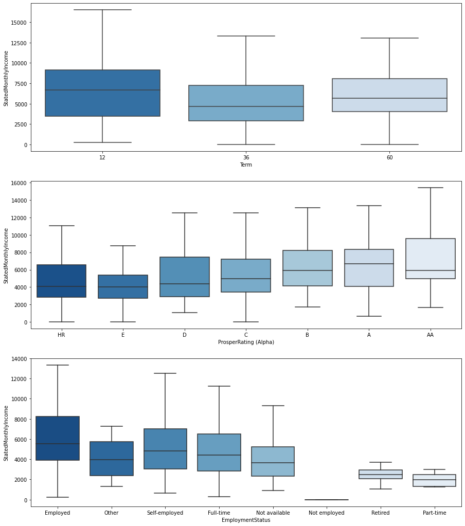

```python
samples = np.random.choice(df.shape[0], int(df.shape[0]*.005), replace = False)
df_samp = df.loc[samples,:]
# boxplots
plt.figure(figsize = [15, 18])
plt.subplot(3, 1, 1)
base_color = sb.color_palette()[0]
sb.boxplot(data = df_samp, x = 'Term', y = 'StatedMonthlyIncome', palette = "Blues_r", showfliers = False)

plt.subplot(3, 1, 2)
base_color = sb.color_palette()[0]
sb.boxplot(data = df_samp, x = 'ProsperRating (Alpha)', y = 'StatedMonthlyIncome', palette = "Blues_r", showfliers = False);

plt.subplot(3, 1, 3)
base_color = sb.color_palette()[0]
sb.boxplot(data = df_samp, x = 'EmploymentStatus', y = 'StatedMonthlyIncome', palette = "Blues_r", showfliers = False);
```

#### Borrowers with better rating also have larger monthly income.

#### Employed, self-employed and full time borrowers have more monthly income than part-time, retired and not employed borrowers.

# Multivariate Exploration

## Borrower APR and Prosper Rating and Term {PointPlot}

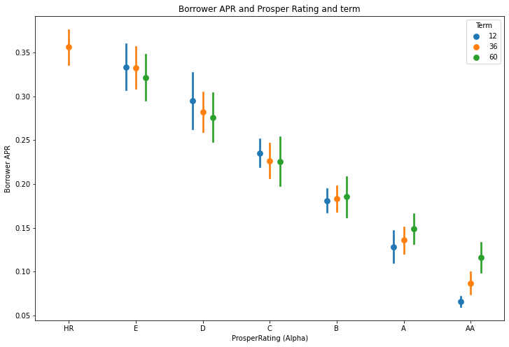

```python
fig = plt.figure(figsize = [12,8])
ax = sb.pointplot(data = df, x = 'ProsperRating (Alpha)', y = 'BorrowerAPR', hue = 'Term',linestyles = '', dodge = 0.3, ci='sd')
plt.title('Borrower APR and Prosper Rating and term')
plt.ylabel('Borrower APR')
ax.set_yticklabels([],minor = True);
```

### the borrower APR decrease with the increase of borrow term for people with HR-D raings

### the borrower APR increase with the increase of borrow term for people with A-AA raings

### the borrower APR still much the same with the increase of borrow term for people with C and B raings

## Borrower APR and EmploymentStatus and Term {PointPlot}

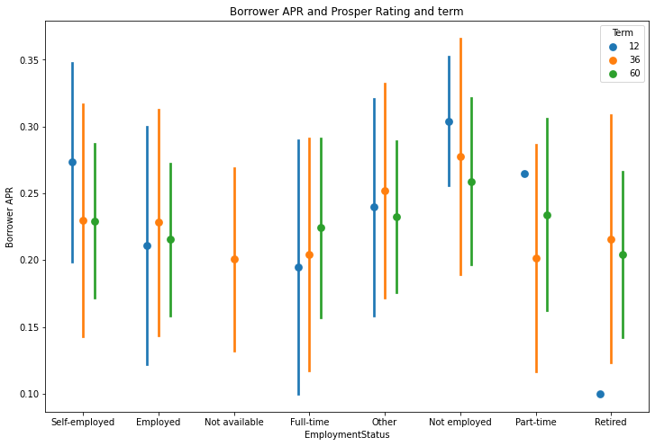

```python
fig = plt.figure(figsize = [12,8])
ax = sb.pointplot(data = df, x = 'EmploymentStatus', y = 'BorrowerAPR', hue = 'Term',linestyles = '', dodge = 0.3, ci='sd')
plt.title('Borrower APR and Prosper Rating and term')
plt.ylabel('Borrower APR')
ax.set_yticklabels([],minor = True);
```

## Borrower APR and Income Range and Term {PointPlot}

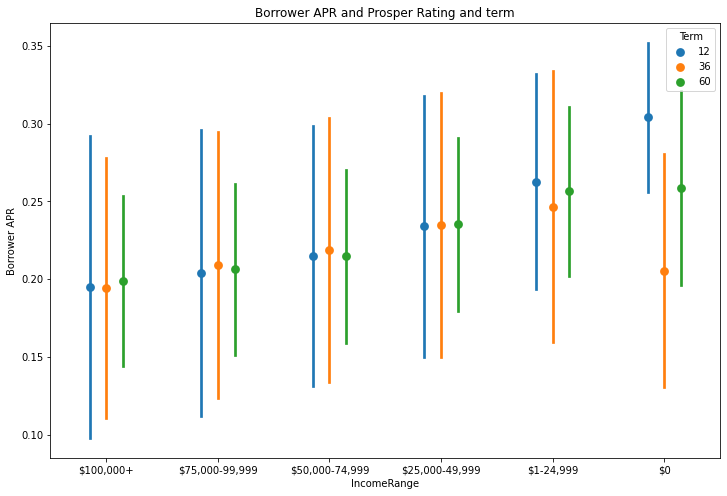

```python
fig = plt.figure(figsize = [12,8])
ax = sb.pointplot(data = df, x = 'IncomeRange', y = 'BorrowerAPR', hue = 'Term',linestyles = '', dodge = 0.3, ci='sd')
plt.title('Borrower APR and Prosper Rating and term')
plt.ylabel('Borrower APR')
ax.set_yticklabels([],minor = True);
```